# Unsupervised Clustering of Card Transactions - Kaggle

```python
!pip install gower
```

```
Downloading gower-0.1.2-py3-none-any.whl (5.2 kB)
```

```python
from google.colab import drive
drive.mount('/content/drive')
```

```python
dataset = '/content/drive/My Drive/Fraud/transaction_fraud.csv'
```

```python
import umap
import gower
import numpy
import pandas
import seaborn as sns
import matplotlib.pyplot as plt
from sklearn.cluster import KMeans
from sklearn.neighbors import NearestNeighbors
from sklearn.ensemble import RandomForestClassifier
from sklearn.model_selection import train_test_split
from sklearn.metrics import confusion_matrix, classification_report, accuracy_score, precision_score, recall_score, f1_score
```

```python
df = pandas.read_csv(dataset)
```

Unsupervised clustering is a powerful tool for grouping observations. Here, we subset 10K transactions from a fraud dataset to find out if there is an intrinsic signal to group transactions.

```python
sample_size = int(0.01 * len(df))

fraud_sample_size = int(0.3 * sample_size)
nonfraud_sample_size = sample_size - fraud_sample_size

fraud_sample = df[df['fraud'] == 1].sample(n=fraud_sample_size, random_state=42)
nonfraud_sample = df[df['fraud'] == 0].sample(n=nonfraud_sample_size, random_state=42)

sample_df = pandas.concat([fraud_sample, nonfraud_sample]).sample(frac=1, random_state=42).reset_index(drop=True)
```

We can see that there are 3 continuous features and 4 categorical features.

```python
sample_df.info()
```

```
<class 'pandas.core.frame.DataFrame'>
RangeIndex: 10000 entries, 0 to 9999
Data columns (total 8 columns):
 #   Column                          Non-Null Count  Dtype
---  ------                          --------------  -----
 0   distance_from_home              10000 non-null  float64
 1   distance_from_last_transaction  10000 non-null  float64
 2   ratio_to_median_purchase_price  10000 non-null  float64
 3   repeat_retailer                 10000 non-null  float64
 4   used_chip                       10000 non-null  float64
 5   used_pin_number                 10000 non-null  float64
 6   online_order                    10000 non-null  float64
 7   fraud                           10000 non-null  float64
dtypes: float64(8)
memory usage: 625.1 KB
```

```python
sample_df.head()
```

|  | distance_from_home | distance_from_last_transaction | ratio_to_median_purchase_price | repeat_retailer | used_chip | used_pin_number | online_order | fraud |
| --- | --- | --- | --- | --- | --- | --- | --- | --- |
| 0 | 6.220133 | 23.000038 | 0.396921 | 1.0 | 1.0 | 0.0 | 0.0 | 0.0 |
| 1 | 8.417660 | 7.594772 | 2.119441 | 1.0 | 0.0 | 0.0 | 0.0 | 0.0 |
| 2 | 2.918439 | 4.962099 | 5.603267 | 1.0 | 0.0 | 0.0 | 1.0 | 1.0 |
| 3 | 6.699053 | 2.345252 | 2.341445 | 1.0 | 0.0 | 0.0 | 0.0 | 0.0 |
| 4 | 34.634723 | 0.293016 | 1.199578 | 1.0 | 1.0 | 0.0 | 1.0 | 0.0 |

```python
sample_df.describe()
```

|  | distance_from_home | distance_from_last_transaction | ratio_to_median_purchase_price | repeat_retailer | used_chip | used_pin_number | online_order | fraud |
| --- | --- | --- | --- | --- | --- | --- | --- | --- |
| count | 10000.000000 | 10000.000000 | 10000.000000 | 10000.000000 | 10000.000000 | 10000.000000 | 10000.000000 | 10000.00000 |
| mean | 36.414503 | 6.768083 | 2.828222 | 0.885600 | 0.331200 | 0.079400 | 0.719800 | 0.30000 |
| std | 82.453323 | 31.107451 | 4.011139 | 0.318312 | 0.470668 | 0.270376 | 0.449119 | 0.45828 |
| min | 0.041889 | 0.001153 | 0.016867 | 0.000000 | 0.000000 | 0.000000 | 0.000000 | 0.00000 |
| 25% | 4.025029 | 0.293527 | 0.573743 | 1.000000 | 0.000000 | 0.000000 | 0.000000 | 0.00000 |
| 50% | 11.001499 | 0.988947 | 1.336352 | 1.000000 | 0.000000 | 0.000000 | 1.000000 | 0.00000 |
| 75% | 31.231312 | 3.562522 | 4.057630 | 1.000000 | 1.000000 | 0.000000 | 1.000000 | 1.00000 |
| max | 1741.873281 | 1872.446884 | 94.132574 | 1.000000 | 1.000000 | 1.000000 | 1.000000 | 1.00000 |

Let's plot the distribution of continuous features. The data is highly skewed, which could impact analysis.

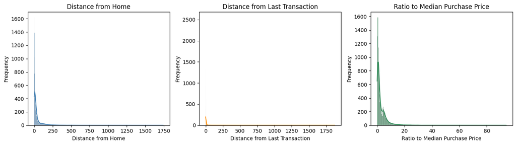

```python
fig, axes = plt.subplots(1, 3, figsize=(14, 4))

sns.histplot(sample_df['distance_from_home'], kde=True, ax=axes[0], color='steelblue', edgecolor='black')
axes[0].set_title('Distance from Home')
axes[0].set_xlabel('Distance from Home')
axes[0].set_ylabel('Frequency')

sns.histplot(sample_df['distance_from_last_transaction'], kde=True, ax=axes[1], color='darkorange', edgecolor='black')
axes[1].set_title('Distance from Last Transaction')
axes[1].set_xlabel('Distance from Last Transaction')
axes[1].set_ylabel('Frequency')

sns.histplot(sample_df['ratio_to_median_purchase_price'], kde=True, ax=axes[2], color='seagreen', edgecolor='black')
axes[2].set_title('Ratio to Median Purchase Price')
axes[2].set_xlabel('Ratio to Median Purchase Price')
axes[2].set_ylabel('Frequency')

plt.tight_layout()
plt.show()
```

After applying a log transformation, the distributions look more balanced. This helps stabilize variance and convert exponential relationships into linear ones.

```python
features = sample_df.drop('fraud', axis=1)
continuous_features = ['distance_from_home', 'distance_from_last_transaction', 'ratio_to_median_purchase_price']

features[continuous_features] = features[continuous_features].apply(numpy.log1p)
```

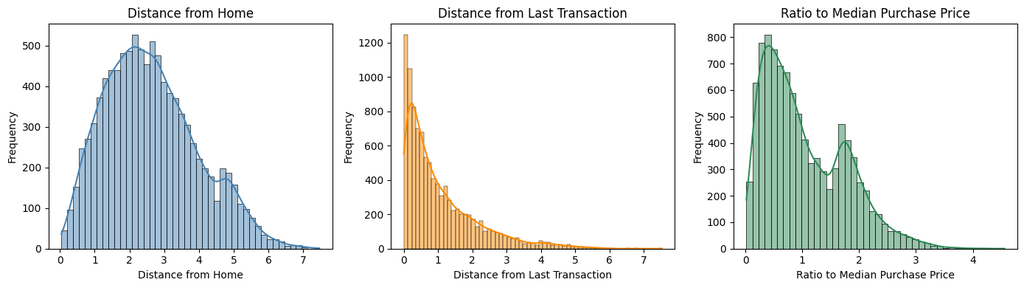

```python
fig, axes = plt.subplots(1, 3, figsize=(14, 4))

sns.histplot(features['distance_from_home'], kde=True, ax=axes[0], color='steelblue', edgecolor='black')
axes[0].set_title('Distance from Home')
axes[0].set_xlabel('Distance from Home')
axes[0].set_ylabel('Frequency')

sns.histplot(features['distance_from_last_transaction'], kde=True, ax=axes[1], color='darkorange', edgecolor='black')
axes[1].set_title('Distance from Last Transaction')
axes[1].set_xlabel('Distance from Last Transaction')
axes[1].set_ylabel('Frequency')

sns.histplot(features['ratio_to_median_purchase_price'], kde=True, ax=axes[2], color='seagreen', edgecolor='black')
axes[2].set_title('Ratio to Median Purchase Price')
axes[2].set_xlabel('Ratio to Median Purchase Price')
axes[2].set_ylabel('Frequency')

plt.tight_layout()
plt.show()
```

Choosing the right distance metric is key for building a KNN graph. Since we have both categorical and continuous features, Gower distance is a solid choice. I'd also like to try Pearson's correlation for continuous features, but that would require a custom implementation.

```python
gower_distance_matrix = gower.gower_matrix(features)
```

Next, we build a KNN graph, where each transaction links to its nearest neighbors, forming an undirected, unweighted network. Then, we construct a shared nearest-neighbor (SNN) graph using Jaccard similarity, which adds weights based on neighborhood overlap. The SNN graph provides a more refined view of the transaction network, better capturing relationships.

```python
def build_snn_matrix(distance_matrix, k=5):
    nn = NearestNeighbors(n_neighbors=k, metric='precomputed')
    nn.fit(distance_matrix)
    _, indices = nn.kneighbors(distance_matrix)

    n = distance_matrix.shape[0]
    snn_matrix = numpy.zeros((n, n))

    neighbor_sets = [set(neighbors) for neighbors in indices]

    for i in range(n):
        for j in range(i + 1, n):
            intersection_size = len(neighbor_sets[i].intersection(neighbor_sets[j]))
            union_size = len(neighbor_sets[i].union(neighbor_sets[j]))
            jaccard_similarity = intersection_size / union_size if union_size != 0 else 0
            snn_matrix[i, j] = jaccard_similarity
            snn_matrix[j, i] = jaccard_similarity

    return snn_matrix


snn_matrix = build_snn_matrix(gower_distance_matrix, k=5)
```

Next, we use UMAP to reduce the data's dimensionality and visualize transaction patterns.

```python
umap_model = umap.UMAP(metric='precomputed', random_state=42, n_neighbors=10)
embedding = umap_model.fit_transform(1 - snn_matrix)
```

We use K-means clustering to identify transaction groups, setting the number of clusters to four. While this works, methods like Leiden could better capture smaller clusters. The figures below show transactions labeled as fraud (blue) and not fraud (white), alongside K-means clusters. The presence of both fraud and non-fraud transactions within clusters suggests meaningful substructures in the data.

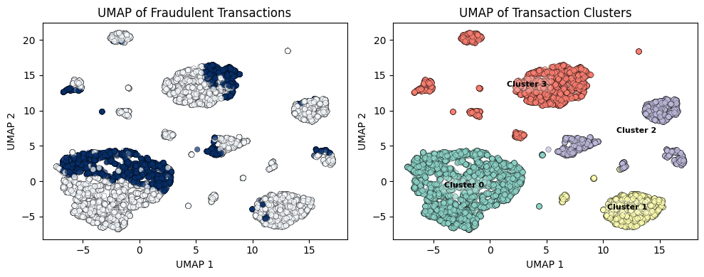

```python
fig, axs = plt.subplots(1, 2, figsize=(10, 4))

labels = sample_df['fraud'].values
sc1 = axs[0].scatter(embedding[:, 0], embedding[:, 1],
                     c=labels, cmap='Blues',
                     s=30, alpha=0.7, edgecolor='k', linewidth=0.3)

axs[0].set_title('UMAP of Fraudulent Transactions')
axs[0].set_xlabel('UMAP 1')
axs[0].set_ylabel('UMAP 2')

n_clusters = 4
kmeans = KMeans(n_clusters=n_clusters, random_state=42)
cluster_labels = kmeans.fit_predict(embedding)

cmap = plt.get_cmap('Set3')
for cluster in range(n_clusters):
    idx = cluster_labels == cluster
    axs[1].scatter(embedding[idx, 0], embedding[idx, 1],
                   s=30, alpha=0.7, edgecolor='k', linewidth=0.3,
                   color=cmap(cluster))

    centroid_x = numpy.mean(embedding[idx, 0])
    centroid_y = numpy.mean(embedding[idx, 1])

    axs[1].text(centroid_x, centroid_y, f'Cluster {cluster}',
                fontsize=8, fontweight='bold',
                horizontalalignment='center', verticalalignment='center',
                bbox=dict(facecolor='white', alpha=0.2, edgecolor='none'))

axs[1].set_title('UMAP of Transaction Clusters')
axs[1].set_xlabel('UMAP 1')
axs[1].set_ylabel('UMAP 2')

plt.tight_layout()
plt.show()
```

Using the SNN graph, we assign fraud scores to transactions by averaging their connections to fraudulent transactions. The score is computed by weighting each connection by the fraud label (0 or 1), penalizing links to non-fraudulent transactions. This ensures higher scores for transactions more likely to be fraudulent.

```python
def compute_weighted_votes(affinity_matrix, labels):
    n = affinity_matrix.shape[0]
    weighted_votes = numpy.zeros(n)

    for i in range(n):
        neighbor_indices = numpy.where(affinity_matrix[i] > 0)[0]

        if neighbor_indices.size == 0:
            weighted_votes[i] = 0.0
        else:
            weights = affinity_matrix[i, neighbor_indices]
            weighted_votes[i] = numpy.sum(weights * labels[neighbor_indices]) / numpy.sum(weights)

    return weighted_votes


weighted_votes = compute_weighted_votes(snn_matrix, labels)
results = pandas.DataFrame({'label': labels, 'score': weighted_votes})
```

A histogram of fraud likelihood scores reveals that most predictions are either 0 or 1. Filtering these out in a second histogram highlights the distribution of intermediate scores. The UMAP visualization of scores closely resembles the fraud labels, suggesting the predictions are on target.

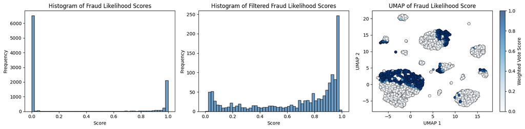

```python
fig, axs = plt.subplots(1, 3, figsize=(16, 4))

axs[0].hist(weighted_votes, bins=50, color='steelblue', edgecolor='black', alpha=0.8)
axs[0].set_xlabel('Score')
axs[0].set_ylabel('Frequency')
axs[0].set_title('Histogram of Fraud Likelihood Scores')

scores = results[results['label'] != results['score']]['score']
axs[1].hist(scores, bins=50, color='steelblue', edgecolor='black', alpha=0.8)
axs[1].set_xlabel('Score')
axs[1].set_ylabel('Frequency')
axs[1].set_title('Histogram of Filtered Fraud Likelihood Scores')

sc = axs[2].scatter(embedding[:, 0], embedding[:, 1],
                    c=results['score'], cmap='Blues', s=30, alpha=0.7,
                    edgecolor='k', linewidth=0.3)
axs[2].set_xlabel('UMAP 1')
axs[2].set_ylabel('UMAP 2')
axs[2].set_title('UMAP of Fraud Likelihood Score')

cbar = fig.colorbar(sc, ax=axs[2], label='Weighted Vote Score')

plt.tight_layout()
plt.show()
```

The confusion matrix and performance metrics indicate strong model accuracy.

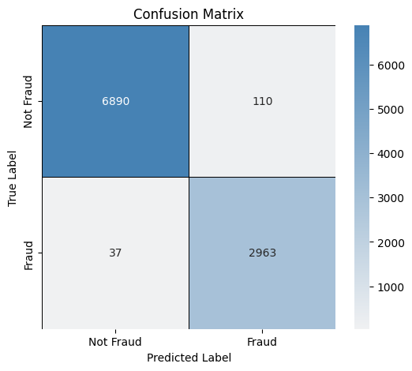

```
              precision    recall  f1-score   support

   Not Fraud       0.99      0.98      0.99      7000
       Fraud       0.96      0.99      0.98      3000

    accuracy                           0.99     10000
   macro avg       0.98      0.99      0.98     10000
weighted avg       0.99      0.99      0.99     10000
```

```python
results['prediction'] = (results['score'] > 0.5).astype(int)

cm = confusion_matrix(results['label'], results['prediction'])

class_names = ['Not Fraud', 'Fraud']
colors = sns.light_palette('steelblue', as_cmap=True)

plt.figure(figsize=(6, 5))
sns.heatmap(cm, annot=True, fmt='d', cmap=colors, xticklabels=class_names, yticklabels=class_names, linewidths=0.5, linecolor='black')
plt.xlabel('Predicted Label')
plt.ylabel('True Label')
plt.title('Confusion Matrix')
plt.show()

print('\n')
class_names = ['Not Fraud', 'Fraud']
print(classification_report(results['label'], results['prediction'], target_names=class_names))
```

Plotting the distributions of continuous features per cluster, split by fraud and non-fraud, reveals clear differences, as expected.

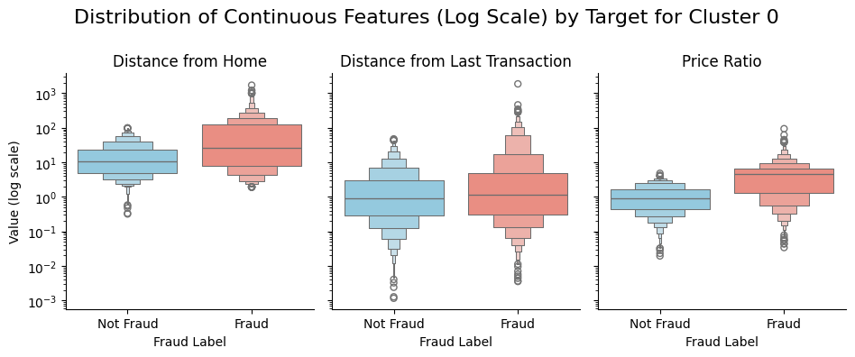

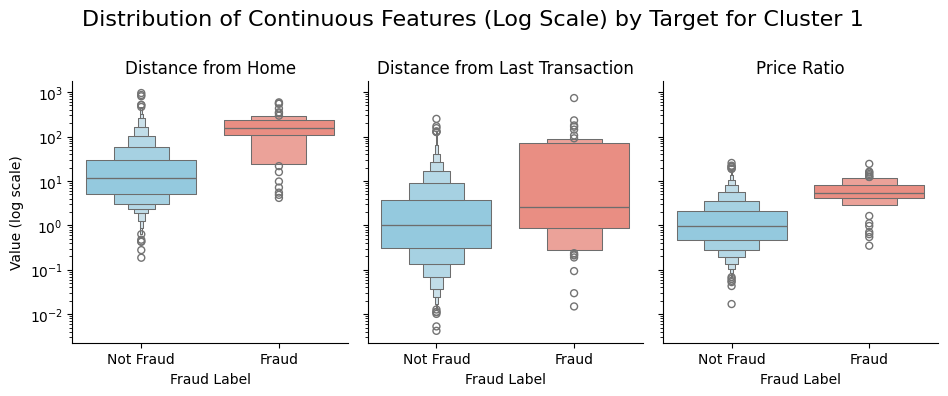

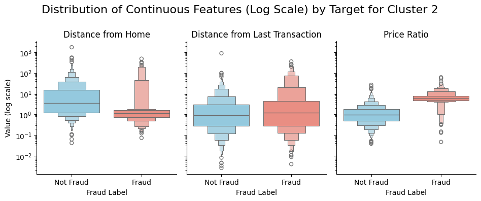

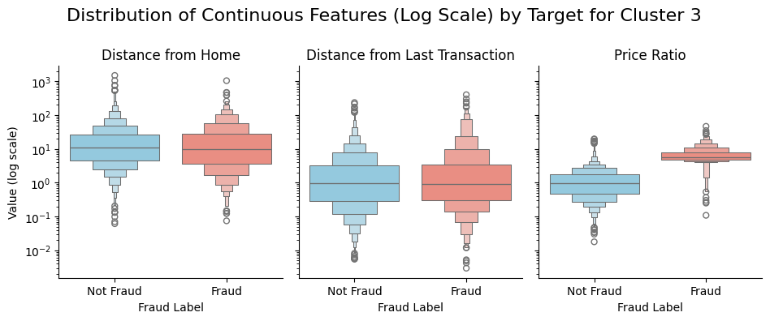

```python
sample_df['cluster'] = cluster_labels
sample_df['fraud_label'] = sample_df['fraud'].map({0: 'Not Fraud', 1: 'Fraud'})

custom_palette = {'Not Fraud': 'skyblue', 'Fraud': 'salmon'}
continuous_features = ['distance_from_home', 'distance_from_last_transaction', 'ratio_to_median_purchase_price']

for cluster in range(n_clusters):
    cluster_df = sample_df[sample_df['cluster'] == cluster]
    melted = cluster_df.melt(id_vars=['fraud_label'], value_vars=continuous_features,
                             var_name='Feature', value_name='Value')

    g = sns.catplot(
      data=melted,
      x='fraud_label',
      y='Value',
      col='Feature',
      hue='fraud_label',
      palette=custom_palette,
      kind='boxen',
      height=4,
      aspect=0.8,
      order=['Not Fraud', 'Fraud'],
      legend=False
    )

    for ax in g.axes.flatten():
        ax.set_yscale('log')

    custom_titles = {
        'distance_from_home': 'Distance from Home',
        'distance_from_last_transaction': 'Distance from Last Transaction',
        'ratio_to_median_purchase_price': 'Price Ratio'
    }

    for ax in g.axes.flat:
        orig_title = ax.get_title()
        feature = orig_title.split(' = ')[-1]
        new_title = custom_titles.get(feature, orig_title)
        ax.set_title(new_title)

    g.fig.subplots_adjust(top=0.8)
    g.fig.suptitle(f'Distribution of Continuous Features (Log Scale) by Target for Cluster {cluster}', fontsize=16)
    g.set_axis_labels('Fraud Label', 'Value (log scale)')

    plt.show()
```

We can also visualize the distributions of categorical features, highlighting differences between fraud and non-fraud transactions.

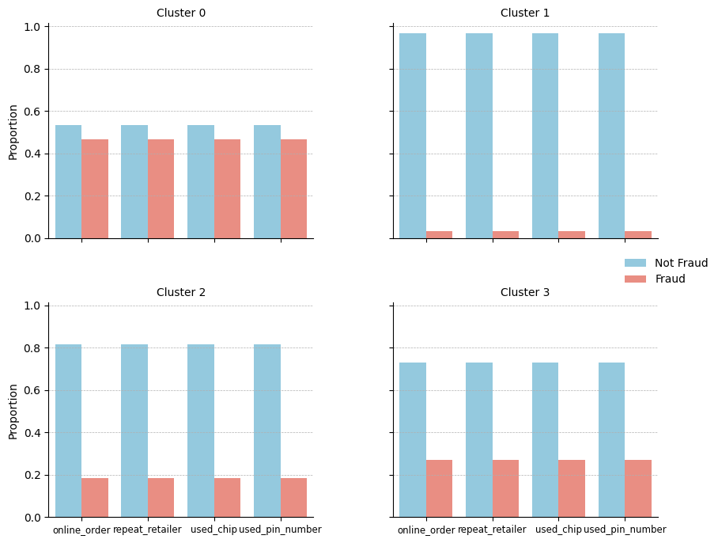

```python
binary_features = ['repeat_retailer', 'used_chip', 'used_pin_number', 'online_order']

melted = sample_df.melt(id_vars=['cluster', 'fraud_label'],
                        value_vars=binary_features,
                        var_name='Feature',
                        value_name='Value')

grouped = melted.groupby(['cluster', 'Feature', 'fraud_label']).size().reset_index(name='count')

grouped['total'] = grouped.groupby(['cluster', 'Feature'])['count'].transform('sum')
grouped['proportion'] = grouped['count'] / grouped['total']

g = sns.catplot(
    data=grouped,
    x='Feature',
    y='proportion',
    hue='fraud_label',
    hue_order=['Not Fraud', 'Fraud'],
    col='cluster',
    kind='bar',
    palette=['skyblue', 'salmon'],
    height=4,
    aspect=1,
    col_wrap=2
)

g.set_titles('Cluster {col_name}')
g.set_axis_labels('', 'Proportion')
g._legend.set_title('')

for ax in g.axes.flatten():
    ax.tick_params(axis='x', labelsize=8.5)
    ax.grid(True, which='major', axis='y', linestyle='--', linewidth=0.5)

plt.subplots_adjust(top=0.88, bottom=0.1, left=0.08, right=0.92, wspace=0.3, hspace=0.3)
plt.show()
```

To see if different features drive fraud prediction in each cluster, we train a separate random forest model for each. Since all clusters contain fraud but represent distinct groups, this approach helps uncover different *types* of fraudulent transactions and tailor models to each.

```python
sample_df['cluster'] = cluster_labels

X_columns = [col for col in sample_df.columns if col not in ['fraud', 'cluster', 'fraud_label']]
continuous_features = ['distance_from_home', 'distance_from_last_transaction', 'ratio_to_median_purchase_price']

model_metrics = {}
feature_importances_dict = {}

for cluster in sorted(sample_df['cluster'].unique()):
    cluster_data = sample_df[sample_df['cluster'] == cluster].copy()

    X = cluster_data[X_columns].copy()
    y = cluster_data['fraud']

    X.loc[:, continuous_features] = X.loc[:, continuous_features].apply(numpy.log1p)

    X_train, X_test, y_train, y_test = train_test_split(X, y, test_size=0.3, random_state=42, stratify=y)

    rf = RandomForestClassifier(n_estimators=100, random_state=42, class_weight='balanced', max_features='sqrt')
    rf.fit(X_train, y_train)

    y_pred = rf.predict(X_test)

    acc = accuracy_score(y_test, y_pred)
    prec = precision_score(y_test, y_pred)
    rec = recall_score(y_test, y_pred)
    f1 = f1_score(y_test, y_pred)

    metrics_df = pandas.DataFrame({
        'Metric': ['Accuracy', 'Precision', 'Recall', 'F1-Score'],
        'Value': [acc, prec, rec, f1]
    })

    model_metrics[cluster] = metrics_df

    importance_df = pandas.DataFrame({
        'feature': X.columns,
        'importance': rf.feature_importances_
    }).sort_values(by='importance', ascending=False)

    feature_importances_dict[cluster] = importance_df

for cluster, metrics_df in model_metrics.items():
    print(f"\nCluster {cluster} Performance Metrics:")
    print(metrics_df.to_string(index=False))
```

```
Cluster 0 Performance Metrics:
   Metric  Value
 Accuracy    1.0
Precision    1.0
   Recall    1.0
 F1-Score    1.0

Cluster 1 Performance Metrics:
   Metric    Value
 Accuracy 0.995772
Precision 1.000000
   Recall 0.875000
 F1-Score 0.933333

Cluster 2 Performance Metrics:
   Metric    Value
 Accuracy 0.993521
Precision 0.988095
   Recall 0.976471
 F1-Score 0.982249

Cluster 3 Performance Metrics:
   Metric    Value
 Accuracy 0.997613
Precision 1.000000
   Recall 0.991189
 F1-Score 0.995575
```

Different features influence fraud prediction across clusters. Continuous features dominate overall, likely due to their richer information. However, in clusters 2 and 3, the second most important feature is categorical. Given the UMAP visualization, these clusters contain distinct subgroups, suggesting that certain categorical features play a stronger role in specific transaction patterns.

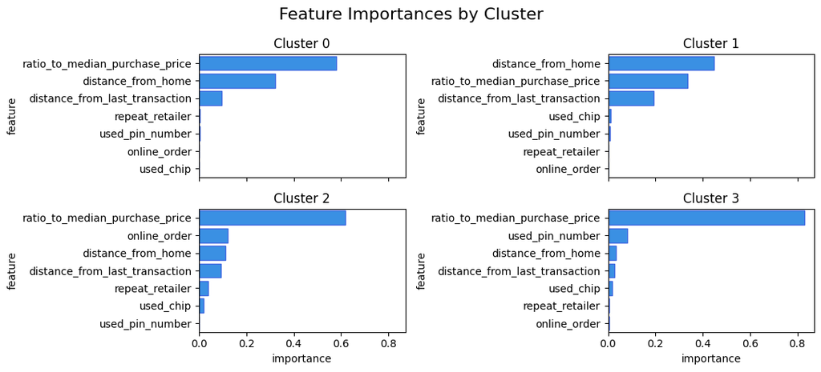

```python
n_clusters = 4

fig, axs = plt.subplots(2, 2, figsize=(11, 5), sharex=True)

axs = axs.flatten()

for i, cluster in enumerate(sorted(feature_importances_dict.keys())):
    imp_df = feature_importances_dict[cluster].copy()
    imp_df = imp_df.sort_values(by='importance', ascending=True)
    order = imp_df['feature'].tolist()

    sns.barplot(x='importance', y='feature', data=imp_df, order=order,
                ax=axs[i], color='dodgerblue', edgecolor='royalblue')

    axs[i].set_title(f'Cluster {cluster}')
    axs[i].invert_yaxis()

fig.suptitle('Feature Importances by Cluster', fontsize=16)
plt.tight_layout()
plt.show()
```